# Exam 3

## Exam 3

#### Question

1. In a deck of strange cards, there are 495 cards. Each card has an image and a color. The amounts are shown in the table below.

   |  | blue | gray | white |
   | --- | --- | --- | --- |
   | dog | 42 | 30 | 73 |
   | gem | 11 | 81 | 74 |
   | tree | 57 | 50 | 77 |

   1. What is the probability a random card is a gem?
   2. What is the probability a random card is a gem given it is gray?
   3. What is the probability a random card is both a tree and white?
   4. What is the probability a random card is blue?
   5. What is the probability a random card is gray given it is a dog?
   6. What is the probability a random card is either a gem or blue (or both)?

#### Solution

   1. $P(\text{gem})$ $=\frac{11+81+74}{495}=0.335$
   2. $P(\text{gem given gray})$ $=\frac{81}{30+81+50}=0.503$
   3. $P(\text{tree and white})$ $=\frac{77}{495}=0.156$
   4. $P(\text{blue})$ $=\frac{42+11+57}{495}=0.222$
   5. $P(\text{gray given dog})$ $=\frac{30}{42+30+73}=0.207$
   6. $P(\text{gem or blue})$ $=\frac{11+81+74+42+11+57-11}{495}=0.535$

#### Question

2. In a deck of strange cards, each card has an image and a color. The chance of drawing a pig is 22.3%. If a pig is drawn, there is a 73.5% chance that it is orange. If a card that is not a pig is drawn, there is a 10.1% chance that it is orange.

   Now, someone draws a random card and reveals it is not orange. What is the chance the card is a pig?

#### Solution

   I'd recommend making a tree. Remember, on the first branch, we put simple probabilities. On the second branches we put conditional probabilites. The results (products) are joint probabilities.

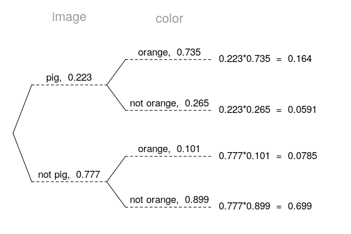

   Determine the appropriate conditional probability.
   $$P(\text{"pig" given "not orange"}) = \frac{0.0591}{0.0591+0.699} = 0.078$$

#### Question

3. In a very large pile of toothpicks, the mean length is 66.59 millimeters and the standard deviation is 3.46 millimeters. If you randomly sample 100 toothpicks, what is the chance the sample mean is between 65.67 and 66.95 millimeters?

#### Solution

   Label the given information.
   $$\begin{aligned}
   \mu &= 66.59\\
   \sigma &= 3.46\\
   n &= 100\\
   \bar{x}_\text{lower} &= 65.67 \\
   \bar{x}_\text{upper} &= 66.95
   \end{aligned}$$
   Find the standard error.
   $$SE = \frac{\sigma}{\sqrt{n}} = \frac{3.46}{\sqrt{100}} = 0.346$$
   Describe the sampling distribution.
   $$\bar{X} \sim \mathcal{N}(66.59,\,0.346)$$

   Draw a sketch.

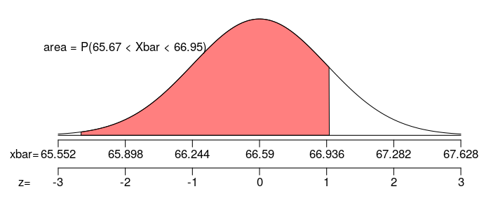

   Calculate a $z$ scores.
   $$z_\text{lower} = \frac{x_\text{lower}-\mu}{SE} = \frac{65.67-66.59}{0.346} = -2.66$$
   $$z_\text{upper} = \frac{x_\text{upper}-\mu}{SE} = \frac{66.95-66.59}{0.346} = 1.04$$
   Determine the probability.
   $$\begin{aligned}
   P(65.67 < X < 66.95) &= \Phi(z_\text{upper}) - \Phi(z_\text{lower}) \\
   &= \Phi(1.04) - \Phi(-2.66) \\
   &= 0.8469
   \end{aligned}$$

#### Question

4. In a game, there is a 43% chance to win a round. You will play 197 rounds.
   1. What is the probability of winning exactly 79 rounds?
   2. What is the probability of winning at least 69 but at most 87 rounds?

#### Solution

   We use the formula for binomial probabilities.
   $$P(X=k) = {n \choose k} (p)^{k}(1-p)^{n-k}$$
   $$P(X=79) = {197 \choose 79} (0.43)^{79}(1-0.43)^{197-79}$$
   $$P(X=79) = {197 \choose 79} (0.43)^{79}(0.57)^{118}$$
   $$P(X=79) = 0.0412$$

   Find the mean.
   $$\mu = np = (197)(0.43) = 84.71$$
   Find the standard deviation.
   $$\sigma = \sqrt{np(1-p)} = \sqrt{(197)(0.43)(1-0.43)} = 6.9487$$
   Make a sketch, specifically try to picture whether you need to add or subtract 0.5 for the continuity correction.

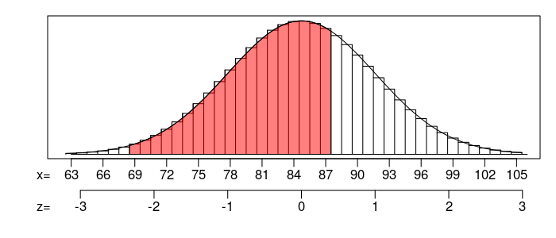

   Find the $z$ scores.
   $$z_1 = \frac{68.5-84.71}{6.9487} = -2.33$$

   $$z_2 = \frac{87.5-84.71}{6.9487} = 0.4$$
   Calculate the probability.
   $$P(69\le X \le 87) = \Phi(0.4) - \Phi(-2.33) = 0.6455$$
   1. $P(X=79) = 0.0412$
   2. $P(69 \le X \le 87) = 0.6455$

#### Question

5. As an ornithologist, you wish to determine the average body mass of *Vireo philadelphicus*. You randomly sample 14 adults of *Vireo philadelphicus*, resulting in a sample mean of 13.53 grams and a sample standard deviation of 1.79 grams. Determine a 99% confidence interval of the true population mean.

#### Solution

   We are given the sample size, sample mean, sample standard deviation, and confidence level.
   $$\begin{aligned}
   n &= 14 \\
   \bar{x} &= 13.53 \\
   s &= 1.79\\
   CL &= 0.99
   \end{aligned}$$
   Determine the degrees of freedom (because we don't know $\sigma$ and we are doing inference so we need to use the $t$ distribution).
   $$df = n-1 = 13$$
   Determine the critical $t$ value, $t^\star$, such that $P(|T|<t^\star) = 0.99$.
   $$t^\star = 3.01$$
   Calculate the standard error.
   $$SE = \frac{s}{\sqrt{n}} = \frac{1.79}{\sqrt{14}} = 0.478$$
   We want to make an inference about the population mean.
   $$\mu ~\approx~ \bar{x}\pm t^\star SE$$
   Determine the bounds.
   $$\begin{aligned}
   CI &= (\bar{x} - t^\star SE,\,\bar{x} + t^\star SE) \\
   &= (13.53 - 3.01\times0.478,\,13.53 + 3.01\times0.478) \\
   &= (12.1,\,15)
   \end{aligned}$$
   We are 99% confident that the population mean is between 12.1 and 15.

#### Question

6. A treatment group of size 10 has a mean of 108 and standard deviation of 12.1. A control group of size 23 has a mean of 99 and standard deviation of 11.3. If you decided to use a signficance level of 0.05, is there sufficient evidence to conclude the treatment causes an effect?

   By using the Welch-Satterthwaite equation, I've calculated the degrees of freedom should be 16.
   1. State the null hypothesis.
   2. State the alternative hypothesis.
   3. Evaluate the critical value. (The critical value is either $z^\star$ or $t^\star$. Determine its value.)
   4. Determine the standard error of the relevant sampling distribution.
   5. Evaluate the absolute value of the test statistic. (The test statistic is either $z_\text{obs}$ or $t_\text{obs}$. Determine its absolute value.)
   6. If possible, evaluate the $p$-value. Otherwise, describe an interval containing the $p$-value.
   7. Do we reject or retain the null?

#### Solution

   We are given unpaired data. We are considering a difference of means. Label the given information.
   $$\begin{aligned}
   n_1 &= 10 \\
   \bar{x}_1 &= 108\\
   s_1 &= 12.1\\
   n_2 &= 23 \\
   \bar{x}_2 &= 99\\
   s_2 &= 11.3\\
   \alpha &= 0.05 \\
   df &= 16
   \end{aligned}$$
   State the hypotheses.
   $$H_0:~~\mu_2-\mu_1 = 0$$
   $$H_A:~~\mu_2-\mu_1 \ne 0$$
   We are using a two-tail test. Find $t^{\star}$ such that $P(|T|>t^{\star})=0.05$ by using a $t$ table.
   $$t^{\star} = 2.12$$
   Calculate the standard error.
   $$\begin{aligned}
   SE &= \sqrt{\frac{(s_1)^2}{n_1}+\frac{(s_2)^2}{n_2}} \\
   &= \sqrt{\frac{(12.1)^2}{10}+\frac{(11.3)^2}{23}} \\
   &= 4.494
   \end{aligned}$$
   Determine the test statistic.
   $$\begin{aligned}
   t_\text{obs} &= \frac{(\bar{x}_2-\bar{x}_1)-(\mu_2-\mu_1)_0}{SE} \\
   &= \frac{(99-108)-(0)}{4.494} \\
   &= -2
   \end{aligned}$$
   Compare $|t_\text{obs}|$ and $t^\star$.
   $$|t_\text{obs}| < t^\star$$
   We can determine an interval for the $p$-value using the $t$ table.
   $$0.05 < p\text{-value} < 0.1$$
   Compare $p$-value and $\alpha$.
   $$p\text{-value} > \alpha$$
   We conclude that we should retain the null hypothesis.
   1. $H_0: ~~\mu_2-\mu_1=0$
   2. $H_\text{A}:~~ \mu_2-\mu_1\ne 0$
   3. $t^\star = 2.12$
   4. $SE = 4.494$
   5. $|t_\text{obs}| = 2$
   6. $0.05 < p\text{-value} < 0.1$
   7. retain the null

#### Question

7. From a very large population, a random sample of 3900 individuals was taken. In that sample, 40.8% were angry. Determine a 90% confidence interval of the population proportion.
   1. Find the lower bound of the confidence interval.
   2. Find the upper bound of the condifence interval.

#### Solution

   Determine $z^\star$ such that $P(|Z|<z^\star) = 0.9$.
   $$z^\star = 1.64$$
   Calculate the standard error.
   $$SE = \sqrt{\frac{\hat{p}(1-\hat{p})}{n}} = \sqrt{\frac{(0.408)(1-0.408)}{3900}} = 0.00787$$
   Calculate the margin of error.
   $$ME = z^\star SE = (1.64)(0.00787) = 0.0129$$
   To find the confidence interval's bounds, find the sample proportion plus or minus the margin of error.
   $$p ~\approx~ \hat{p} \pm ME$$
   Determine the interval.
   $$(0.395\,,~ 0.421)$$
   We are 90% confident that the true population proportion is between 39.5% and 42.1%.
   1. The lower bound = 0.395, which can also be expressed as 39.5%.
   2. The upper bound = 0.421, which can also be expressed as 42.1%.

#### Question

8. An experiment is run with a treatment group of size 104 and a control group of size 106. The results are summarized in the table below.

   |  | treatment | control |
   | --- | --- | --- |
   | green | 37 | 49 |
   | not green | 67 | 57 |

   Using a significance level of 0.2, determine whether the treatment causes an effect on the proportion of cases that are green.
   1. State the null hypothesis.
   2. State the alternative hypothesis.
   3. Evaluate the critical value. (The critical value is either $z^\star$ or $t^\star$. Determine its value.)
   4. Determine the standard error of the relevant sampling distribution.
   5. Evaluate the absolute value of the test statistic. (The test statistic is either $z_\text{obs}$ or $t_\text{obs}$. Determine its absolute value.)
   6. If possible, evaluate the $p$-value. Otherwise, describe an interval containing the $p$-value.
   7. Do we reject or retain the null?

#### Solution

   State the hypotheses.
   $$H_0:~~ p_2-p_1 = 0$$
   $$H_\text{A}: ~~ p_2-p_1 \ne 0$$
   Find $z^\star$ such that $P(|Z|>z^\star) = 0.2$.
   $$z^\star = \Phi^{-1}\left(1-\frac{\alpha}{2}\right) = 1.28$$
   Determine the sample proportions.
   $$\hat{p}_1 = \frac{37}{104} = 0.356$$
   $$\hat{p}_2 = \frac{49}{106} = 0.462$$
   Determine the difference of sample proportions.
   $$\hat{p}_2-\hat{p}_1 = 0.462-0.356 = 0.106$$
   Determine the pooled proportion (because the null assumes the population proportions are equal).
   $$\hat{p} = \frac{37+49}{104+106} = 0.41$$
   Determine the standard error.
   $$\begin{aligned}
   SE &= \sqrt{\frac{\hat{p}(1-\hat{p})}{n_1}+\frac{\hat{p}(1-\hat{p})}{n_2}} \\[1em]
   &= \sqrt{\frac{(0.41)(0.59)}{104}+\frac{(0.41)(0.59)}{106}} \\[1em]
   &= 0.0679
   \end{aligned}$$
   We can be more specific about what the null hypothesis claims.
   $$H_0:~~~~ \hat{P}_2-\hat{P}_1 ~\sim~ \mathcal{N}(0,\,0.0679)$$
   We want to describe how unusual our observation is under the null by finding the $p$-value. To do so, first find the $z$ score.
   $$\begin{aligned}
   z &= \frac{(\hat{p}_2-\hat{p}_1)-(p_2-p_1)_0}{SE}\\
   &= \frac{(0.462-0.356)-0}{0.0679} \\
   &= 1.56
   \end{aligned}$$
   Determine the $p$-value.
   $$\begin{aligned}
   p\text{-value} &= 2\cdot \Phi(-|z|)\\
   &= 2\cdot \Phi(-1.56)\\
   &= 0.1188
   \end{aligned}$$
   Compare the $p$-value to the signficance level.
   $$p\text{-value} < \alpha$$
   So, we reject the null hypothesis. Thus the difference in proportions is significant.
   1. $H_0: ~~p_2-p_1=0$
   2. $H_\text{A}:~~ p_2-p_1\ne 0$
   3. $z^\star = 1.28$
   4. $SE = 0.0679$
   5. $|z_\text{obs}| = 1.56$
   6. $p\text{-value} = 0.1188$
   7. reject the null